# 09.Example 3

Modified

We 2026-09-16 13:21

## Given:

Hot air flows with a mass rate of $\dot{m} = 0.05\ \frac{\mathrm{kg}}{\mathrm{s}}$ through an uninsulated sheet metal duct of diameter $D = 0.15\ \mathrm{m}$, which is in the crawlspace of a house. The hot air enters at $103\ \mathrm{°C}$ and, after a distance of $L = 5\ \mathrm{m}$, cools to $85\ \mathrm{°C}$. The heat transfer coefficient between the duct outer surface and the ambient air at $T_\infty = 0\ \mathrm{°C}$ is known to be $h_o = 6\ \frac{\mathrm{W}}{\left(\mathrm{K} \cdot \mathrm{m}^{2}\right)}$.

## Required:

1. Calculate the heat loss $(W)$ from the duct over the length $L$.
2. Determine the heat flux and the duct surface temperature at $x = L$.

## Solution:

Start first by defining all of the given values.

$$\dot{m} = 0.05\ \frac{\mathrm{kg}}{\mathrm{s}}$$
$$D = 0.15\ \mathrm{m}$$
$$T_{m,0} = 103\ \mathrm{°C} = 376.15\ \mathrm{K}$$
$$L = 5\ \mathrm{m}$$
$$T_{m,L} = 85\ \mathrm{°C} = 358.15\ \mathrm{K}$$
$$T_\infty = 0\ \mathrm{°C} = 273.15\ \mathrm{K}$$
$$h_o = 6\ \frac{\mathrm{W}}{\left(\mathrm{K} \cdot \mathrm{m}^{2}\right)}$$

A sketch of the system is shown below.

Figure 1: System Sketch

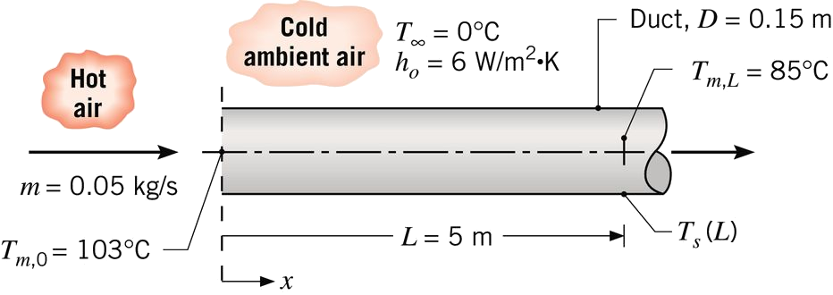

The the mean temperature $T_m$ is given by

$$\bar{T}_m = \frac{T_{m0} + T_{mL}}{2} = 367.1\ \mathrm{K} = 94.0\ \mathrm{°C}$$

Table A.4 for air at $\bar{T}_m$ may now be used to obtain the various material properties needed. This is shown below.

$$T_A = 350\ \mathrm{K} = 76.9\ \mathrm{°C}$$
$$T_B = 400\ \mathrm{K} = 126.9\ \mathrm{°C}$$
$$c_{p,A} = 1.009\ \frac{\mathrm{kJ}}{\left(\mathrm{K} \cdot \mathrm{kg}\right)}$$
$$c_{p,B} = 1.014\ \frac{\mathrm{kJ}}{\left(\mathrm{K} \cdot \mathrm{kg}\right)}$$
$$c_p = \frac{\bar{T_m} - T_A}{T_B - T_A}(c_{pB} - c_{pA}) + c_{pA} = 1.011\ \frac{\mathrm{kJ}}{\left(\mathrm{K} \cdot \mathrm{kg}\right)}$$

The other properties needed will be evaluated at $T_{m,L}$. This is shown below.

$$T_A = 350\ \mathrm{K} = 76.9\ \mathrm{°C}$$
$$T_B = 400\ \mathrm{K} = 126.9\ \mathrm{°C}$$
$$\mu_A = 2.082\times 10^{-5}\ \frac{\mathrm{N} \cdot \mathrm{s}}{\mathrm{m}^{2}}$$
$$\mu_B = 2.301\times 10^{-5}\ \frac{\mathrm{N} \cdot \mathrm{s}}{\mathrm{m}^{2}}$$
$$\mu = \frac{\bar{T_{mL}} - T_A}{T_B - T_A}(\mu_B - \mu_A) + \mu_A = 2.118\times 10^{-5}\ \frac{\mathrm{N} \cdot \mathrm{s}}{\mathrm{m}^{2}}$$
$$k_A = 0.03\ \frac{\mathrm{W}}{\left(\mathrm{K} \cdot \mathrm{m}\right)}$$
$$k_B = 0.0338\ \frac{\mathrm{W}}{\left(\mathrm{K} \cdot \mathrm{m}\right)}$$
$$k = \frac{\bar{T_{mL}} - T_A}{T_B - T_A}(k_B - k_A) + k_A = 30.62\ \frac{\mathrm{mW}}{\left(\mathrm{K} \cdot \mathrm{m}\right)}$$
$$Pr_A = 0.7$$
$$Pr_B = 0.69$$
$$Pr = \frac{\bar{T_{mL}} - T_A}{T_B - T_A}(Pr_B - Pr_A) + Pr_A = 0.6984$$

Now that all material properties have been found, the total heat rate may be found by

Answer, part (a): $q = \dot{m} c_p (T_{mL} - T_{m0}) = -909.6\ \mathrm{W}$

The thermal resistance circuit for the outlet is shown below.

Figure 2: Thermal Circuit

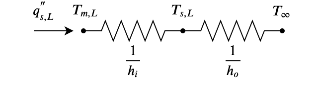

The Reynolds number for the outlet location is given by

$$Re_D=\frac{\rho u_m D}{\mu}$$

However, the mean velocity at this location is not known. Recall that the mass flow rate is given by

$$\dot{m}=\rho u_m A_c$$

Rearranging shows

$$\rho u_m = \frac{\dot{m}}{A_c}$$

Using this expression in the Reynolds number expression for a circular cross section shows

$$Re_D = \frac{4 \dot{m}}{\pi D \mu} = 2.004\times 10^{4}$$

Since the Reynolds number is greater than the critical Reynolds number for this type of flow (i.e. $Re_D \gt Re_{c,D} = 2300$), the flow is turbulent. To determine if the flow is fully developed, the length over the diameter must be greater than $10$. This is shown below.

$$\frac{L}{D} = 33.3$$

Since the length-diameter ratio is greater than $10$, the flow is fully developed. The appropriate empirical relation may now be selected. This is shown below.

$$Nu_D = 0.023 Re_D^{\frac{4}{5}} Pr^{0.3} = 57.08$$

The local convective coefficient may now be found from the definition of the Nusselt number. This is shown below.

$$Nu_D=\frac{h D}{k}$$

Solving for the local convective coefficient (the convective coefficient on the inside) shows

$$h_i = \frac{Nu_D k}{D} = 11.65\ \frac{\mathrm{W}}{\left(\mathrm{K} \cdot \mathrm{m}^{2}\right)}$$

Referring to the thermal resistance circuit, it may be seen that the heat flux is given by

Answer, part (b1): $q^{\prime \prime}_s = \frac{T_{mL}-T_\infty}{\frac{1}{h_i}+\frac{1}{h_o}} = 336.6\ \frac{\mathrm{W}}{\mathrm{m}^{2}}$

Now that the heat flux is known, the surface temperature at the outlet may be found. Referring to the thermal resistance circuit, it may be seen that the following is true.

$$q^{''}_s=\frac{T_{m,L}-T_{s,L}}{\frac{1}{h_i}}$$

Rearranging shows

Answer, part (b2): $T_{s,L} = T_{mL}-\frac{q^{\prime \prime}_s}{h_i} = 329.3\ \mathrm{K} = 56.1\ \mathrm{°C}$